# Session 2: R Basics - looping, if else, functions, stats package, reading in data

# Plotting

Here, we will go through the most common base R plotting functions. However, they are not visually appealing and in the next session, we will talk about `ggplot2`

## Sample data

Here, we will use the `airquality` data from the `datasets` library in R.

| Ozone | Solar.R | Wind | Temp | Month | Day |
| --- | --- | --- | --- | --- | --- |
| 41 | 190 | 7.4 | 67 | 5 | 1 |
| 36 | 118 | 8.0 | 72 | 5 | 2 |
| 12 | 149 | 12.6 | 74 | 5 | 3 |
| 18 | 313 | 11.5 | 62 | 5 | 4 |
| NA | NA | 14.3 | 56 | 5 | 5 |
| 28 | NA | 14.9 | 66 | 5 | 6 |
| 23 | 299 | 8.6 | 65 | 5 | 7 |
| 19 | 99 | 13.8 | 59 | 5 | 8 |
| 8 | 19 | 20.1 | 61 | 5 | 9 |
| NA | 194 | 8.6 | 69 | 5 | 10 |

[output cut: 143 more lines]

The data are stored in the “long” format, which makes plotting a lot easier.

## Scatter plots

The scatter plot is a bi-axial plot highlighting two features:

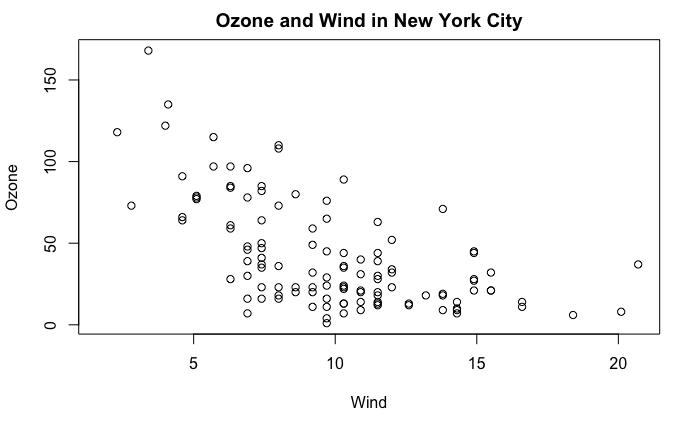

There are a number of parameters that can be set to alter the appearance of the plot:

```r
?par
```

Here is an example of an altered plot:

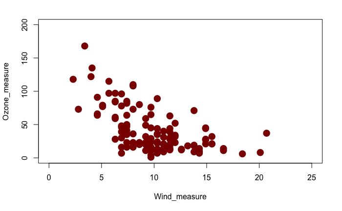

### Adding things to a plot

We can now also add further things to a plot. As an example, we perform a linear regression between the Wind and Ozone measures.

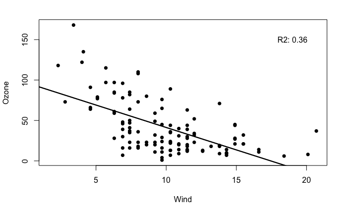

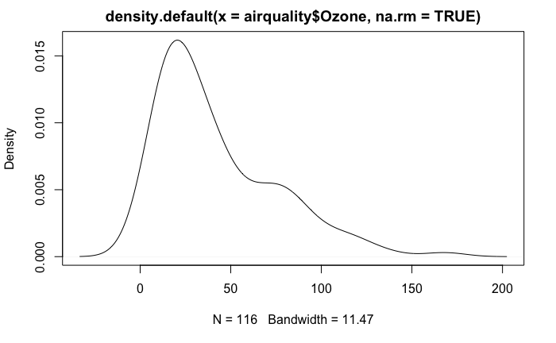

## Boxplots

Finally, we can also plot boxplots in R.

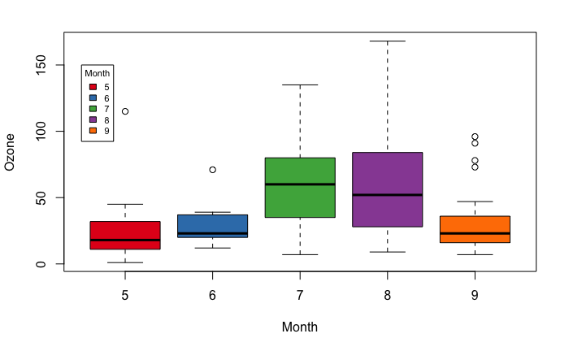